# Shopco_Rscript

Shreya Nadkarni

10th November 2021

*# ShopCo Case*

*Shopco, owner of various malls in United States, just initiated a real-time mobile message system in one of their malls, by which a short text is sent to consumers on their mobile phone right after their first purchase in the mall.* *You are hired as a business analyst to (1) investigate the role of real-time mobile message in the mall on consumer’s intention to keep shopping and (2) to classify consumers using sales data and (3) to further cluster consumers of high loyalty status.*

*Below are more details about the mall and its data.*

*consumer_id: Each consumer has a unique consumer identifier (consumer_id) that gets assigned as soon as the consumer creates a new profile on the mobile app. Each consumer has only one consumer_id.*

*age: Age of the consumer (in years).*

*gender: Gender of the consumer (male (1) vs female(0)).*

*loyalty_status: The mall operator on the basis of past spending of the consumer assigns a loyalty status: low (1) and high (0). Low is the low loyalty whereas high is the high loyalty to the mall. Shopco internally assigns loyalty status to each consumer depending upon their past purchase history.*

*from_second_store_sales: The amount spent in dollars from the second store onward in the same shopping trip. This is the sales (in dollars) of all the purchases that a consumer makes after the first purchase*

*realtime_message: This shows if a consumer received a real-time mobile message or not. For the consumer who receives a real-time mobile message, realtime_message is marked one, otherwise zero*

*Do the following tasks and answer the questions according to the tasks’ output.*

## Task 1: Explore and tranform your data*

*(a) Explore the dataset using 5 functions*

*(b) Converting any column(s) that is supposed to be treated as a factor.*

*(c) Compute relevant summary stats for continuous and categorical variables.*

```r
# (a) Explore the dataset

dim(shopco)
```

```
## [1] 9032    6
```

```r
str(shopco)
```

```
## 'data.frame':    9032 obs. of  6 variables:
##  $ consumer_id            : num  5.92e+09 1.66e+09 3.86e+09 2.30e+09 1.59e+10 ...
##  $ age                    : int  66 66 66 66 66 65 65 65 65 63 ...
##  $ loyalty_status         : int  1 0 1 0 0 0 0 1 0 1 ...
##  $ gender                 : int  0 0 0 0 1 1 0 0 0 1 ...
##  $ from_second_store_sales: num  0 103 0 0 0 ...
##  $ realtime_message       : int  0 1 1 1 1 1 1 0 0 1 ...
```

```r
colnames(shopco)
```

```
## [1] "consumer_id"             "age"
## [3] "loyalty_status"          "gender"
## [5] "from_second_store_sales" "realtime_message"
```

```r
head(shopco)
```

```
##   consumer_id age loyalty_status gender from_second_store_sales
## 1  5915774351  66              1      0                     0.0
## 2  1655582358  66              0      0                   102.6
## 3  3861455358  66              1      0                     0.0
## 4  2303345354  66              0      0                     0.0
## 5 15887293516  66              0      1                     0.0
## 6  3153352354  65              0      1                     0.0
##   realtime_message
## 1                0
## 2                1
## 3                1
## 4                1
## 5                1
## 6                1
```

```r
tail(shopco)
```

```
##      consumer_id age loyalty_status gender from_second_store_sales
## 9027 58339483515  18              0      0                    0.00
## 9028 58339483514  18              0      0                    0.00
## 9029 58339483511  18              0      0                    0.00
## 9030  5833948352  18              0      0                   42.12
## 9031  5762439354  18              0      0                    0.00
## 9032  1519464359  14              0      0                    0.00
##      realtime_message
## 9027                0
## 9028                0
## 9029                0
## 9030                0
## 9031                0
## 9032                1
```

```r
# (b) Convert columns gender, loyalty_status and realtime_message that is supposed to be treated as a factor

shopco$gender <- as.factor(shopco$gender)
shopco$loyalty_status <- as.factor(shopco$loyalty_status)
shopco$realtime_message <- as.factor(shopco$realtime_message)


# (c) Descriptive Analysis
## summary stats for continuous variables: age, from_second_store_sales


summary(shopco$age)
```

```
##    Min. 1st Qu.  Median    Mean 3rd Qu.    Max.
##   14.00   23.00   30.00   31.05   36.00   66.00
```

```r
summary(shopco$from_second_store_sales)
```

```
##    Min. 1st Qu.  Median    Mean 3rd Qu.    Max.
##    0.00    0.00    0.00   34.65   22.72 1566.00
```

```r
## summary stats for categorical variables: gender, loyalty_status, realtime_message

table(shopco$gender)
```

```
##
##    0    1
## 6903 2129
```

```r
table(shopco$loyalty_status)
```

```
##
##    0    1
## 5763 3269
```

```r
table(shopco$realtime_message)
```

```
##
##    0    1
## 4516 4516
```

```r
## Average sales from second store (from_second_store_sales) grouped by the receipt of real time message (realtime_message)

shopco %>% group_by(realtime_message) %>% summarise(mean(from_second_store_sales))
```

```
## # A tibble: 2 × 2
##   realtime_message `mean(from_second_store_sales)`
##   <fct>                                      <dbl>
## 1 0                                           32.6
## 2 1                                           36.7
```

**Question 1: Using the descriptive analysis*

*(a) What is the average age of consumers?* *(b) How much, on average, consumers spend on sales from second store onward?* *(c) How many consumers are female vs male?* *(d) How many consumers are there in each loyalty status?* *(f) Did consumers who received the real time message purchase, on average, more from second store onward than the customers who did not receive the message?*

**RESPONSE**

*The average age of a consumer is 31.05*

*From the data, we can state that, on an average $34.65 consumer spend on sales from second store.*

*There are 2129 male consumers and 6903 female consumers.*

*There are 3269 consumers who fall in the low loyalty status group while on the other hand there are 5763 consumer who are considered to be highly loyal (Falling under high loyalty Status).*

*Consumers whose average spending was 32.6 dollar did not receive real time message, while on the other hand, consumers with an average spending of 36.7 dollars received real time message.*

## Task 2: Multiple Regression Analysis

```r
reg_from_second_store_sales<- lm(from_second_store_sales ~  age + gender + loyalty_status + realtime_message + realtime_message*loyalty_status , data = shopco)
summary(reg_from_second_store_sales)
```

```
##
## Call:
## lm(formula = from_second_store_sales ~ age + gender + loyalty_status +
##     realtime_message + realtime_message * loyalty_status, data = shopco)
##
## Residuals:
##     Min      1Q  Median      3Q     Max
##  -66.70  -38.62  -28.67  -11.98 1523.46
##
## Coefficients:
##                                   Estimate Std. Error t value Pr(>|t|)
## (Intercept)                        17.1697     3.6383   4.719 2.40e-06 ***
## age                                 0.6389     0.1038   6.156 7.79e-10 ***
## gender1                            -1.7944     2.2683  -0.791 0.428914
## loyalty_status1                    -9.9823     2.8296  -3.528 0.000421 ***
## realtime_message1                   7.3564     2.4051   3.059 0.002230 **
## loyalty_status1:realtime_message1 -11.0007     3.9904  -2.757 0.005849 **
## ---
## Signif. codes:  0 '***' 0.001 '**' 0.01 '*' 0.05 '.' 0.1 ' ' 1
##
## Residual standard error: 91.11 on 9026 degrees of freedom
## Multiple R-squared:  0.01331,    Adjusted R-squared:  0.01277
## F-statistic: 24.36 on 5 and 9026 DF,  p-value: < 2.2e-16
```

**Question 2**: Interpret the multiple regression analysis results by answering these questions:

*(a) Is this a valid model? Explain why or why not.* *(b) Is this a good fit? Explain why or why not.* *(c) Which predictors have a significant impact on sales from second store onward? Explain why.* *(d) According to this model, does the real time message increase the sales from second store onward? Is this impact the same for consumers with different loyalty status? Explain.*

**RESPONSE 1- Yes, the model is valid as the p-value for F-statistics is less than 0.05 as well as, at least one of the coefficients are non-zero.*

*2- Looking at the R squared value, which is just 0.01331 we can explain only 1.33% of variance in our data with this model. Therefore, this is not a good model.*

*3- From the values, we can state that, since the coefficient of age, loyalty-status, realtime_message and interaction of loyalty_status and realtime_message have p-value <0.05 and therefore they have significant impact on sales where as on the other hand gender doesn’t have a significant impact on the sales as its p-value is greater than 0.05.*

*4-Yes, receiving a real time message increases the sales and this can been seen that through an increase of $7.36 dollar over who did not receive real time message. And for loyalty status, we see that consumers are in low status they spend average 9.98 dollars less than who are in the high loyalty status.*

## Task 3: Classification

*The task focuses on using the shopco data set to develop classifiers that classify consumers into loyalty classes low and high*

*First, creating train and test data sets. Then, developing a logistic regression classifier and a KNN classifier.*

### Task 3.1: Create training and testing set

*Using 80:20 split ratio to divide the data into train and test sets. Set seed to 1234 for simplicity.*

```r
set.seed(1234)

#Using 80:20 split ratio (most common) which means 80% of the data would be in train set and 20% would be in test set

set.seed(1234)

smp_size <- floor(0.80 * nrow(shopco))

train_ind <- sample(seq_len(nrow(shopco)), size = smp_size)

train <- shopco[train_ind, ]
test <- shopco[-train_ind, ]
```

### Task 3.2: Developing Logistic Regression

*Runing a logistic regression analysis on age, gender and from_second_store_sales as predictors and loyalty_status as the response.*

```r
glmfit = glm(loyalty_status ~ age + gender + from_second_store_sales, data = train, family = binomial)
summary(glmfit)
```

```
##
## Call:
## glm(formula = loyalty_status ~ age + gender + from_second_store_sales,
##     family = binomial, data = train)
##
## Deviance Residuals:
##     Min       1Q   Median       3Q      Max
## -1.1460  -0.9876  -0.8544   1.3299   2.4852
##
## Coefficients:
##                           Estimate Std. Error z value Pr(>|z|)
## (Intercept)              0.1823763  0.0880753   2.071   0.0384 *
## age                     -0.0230957  0.0027882  -8.283  < 2e-16 ***
## gender1                  0.1819688  0.0579812   3.138   0.0017 **
## from_second_store_sales -0.0027260  0.0003639  -7.490 6.88e-14 ***
## ---
## Signif. codes:  0 '***' 0.001 '**' 0.01 '*' 0.05 '.' 0.1 ' ' 1
##
## (Dispersion parameter for binomial family taken to be 1)
##
##     Null deviance: 9457.9  on 7224  degrees of freedom
## Residual deviance: 9300.5  on 7221  degrees of freedom
## AIC: 9308.5
##
## Number of Fisher Scoring iterations: 4
```

*Compute the confusion matrix, accuracy, sensitivity and specificity. Use the cut-off probability of 0.45, when the reference level is high loyalty status.*

```r
# Compute the confusion matrix, accuracy, sensitivity and specificity
## Predict the probability of low loyalty status in the test data set using the fitted logistic regression

glmprobs = predict(glmfit, test, type = "response")

glmpred = ifelse(glmprobs>0.45,1,0)

##Use table() function to produce a confusion matrix
table(test$loyalty_status, glmpred)
```

```
##    glmpred
##        0    1
##   0 1125   28
##   1  628   26
```

```r
# Accuracy: (TP + TN) / (TP + TN + FP + FN)
mean(test$loyalty_status == glmpred)
```

```
## [1] 0.6369673
```

```r
# True high (positive) rate (sensitivity or recall): TP / (TP + FN)
sum(test$loyalty_status == 1 & glmpred == 1)/sum(test$loyalty_status == 1)
```

```
## [1] 0.03975535
```

```r
# True low (negative) rate (specificity): TN / (TN + FP)

sum(test$loyalty_status == 0 & glmpred == 0)/sum(test$loyalty_status == 0)
```

```
## [1] 0.9757155
```

*Plot the ROC curve and compute the AUC.*

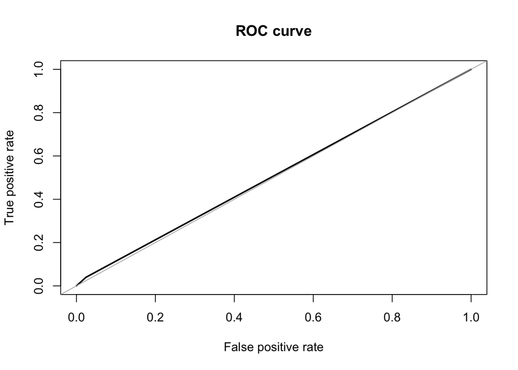

```
## Area under the curve (AUC): 0.508
```

```r
## ROC curve for the logistic regression model

roc.curve(test$loyalty_status, glmpred)
```

### Task 3.3: Developing a KNN model

*Use age, gender and from_second_store_sales to develop a KNN model to classify consumer into low and high loyalty status for different values of k. Choose k to be equal to 1 and 40. Please set seed to 1234.*

*## k = 1*

```r
set.seed(1234)  # used when we want to reproduce results.

# knn classifier for k=1
# Confusion matrix
knn_1 <- knn(as.matrix(train[,c("age","from_second_store_sales", "gender")]), as.matrix(test[,c("age","from_second_store_sales","gender")]), train$loyalty_status, k = 1)
summary(knn_1)
```

```
##    0    1
## 1408  399
```

```r
table(test$loyalty_status,knn_1)
```

```
##    knn_1
##       0   1
##   0 922 231
##   1 486 168
```

```r
## accuracy

mean(knn_1==test$loyalty_status)
```

```
## [1] 0.6032097
```

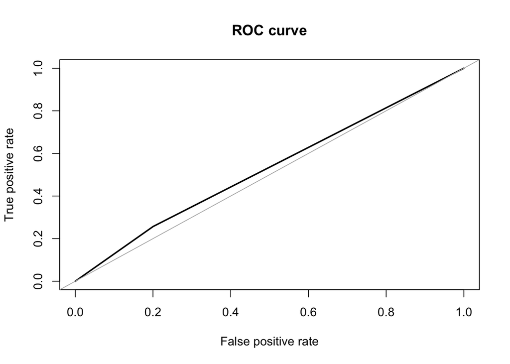

```
## Area under the curve (AUC): 0.528
```

```r
# ROC curve

roc.curve(test$loyalty_status, knn_1)
```

*## k = 40*

```r
set.seed(1234)  # used when we want to reproduce results.

# knn classifier for k=40

# Confusion matrix

knn_40 <- knn(as.matrix(train[,c("age","from_second_store_sales", "gender")]), as.matrix(test[,c("age","from_second_store_sales","gender")]), train$loyalty_status, k = 40)
summary(knn_40)
```

```
##    0    1
## 1588  219
```

```r
table(test$loyalty_status,knn_40)
```

```
##    knn_40
##        0    1
##   0 1041  112
##   1  547  107
```

```r
## accuracy
mean(knn_40==test$loyalty_status)
```

```
## [1] 0.6353071
```

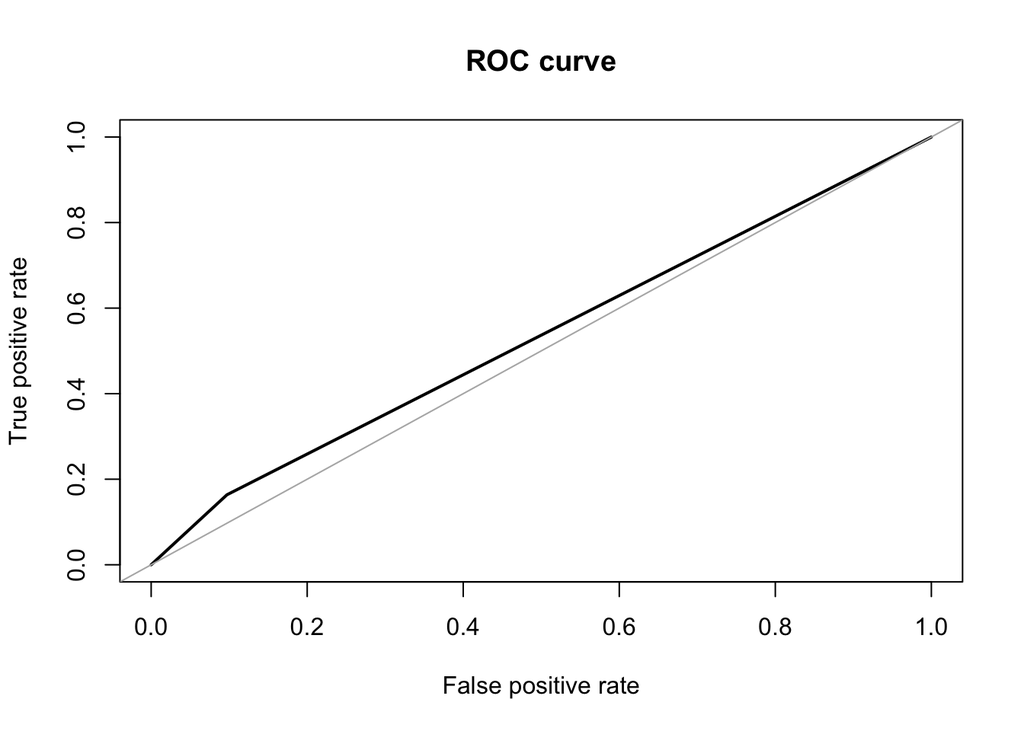

```
## Area under the curve (AUC): 0.533
```

```r
# ROC curve
roc.curve(test$loyalty_status, knn_40)
```

**Question 3 Use metrics derived from confusion matrix and ROC Curve results to answer the following questions:*

*(a) What are the sensitivity and the specificity of the logistic regression classifier? Interpret the values.* *(b) What do the ROC curve and AUC for the logistic regression classifier show? Explain.* *(c) Which of these methods (logistic regression and knn with different k values) appear to provide the best results on this data? Use accuracy and AUC to compare.*

*## Task 4: Clustering*

*This task focuses on consumers with high_loyalty status (= 0) and you are asked to use the shopco data set to cluster high loyalty status consumers using age and from_second_store_sales.*

### Task 4.1: K Means Clustering

*Runing a cluster analysis on age and sales on second store onwards using K-means clustering. Assume there are 3 clusters. Print the total cluster variation and between_SS/total_SS ratio.*

```r
set.seed(1234) # used when we want to reproduce results.

# Create a dataset for Consumers of the high loyalty status (= 0)
shopco = filter(shopco,loyalty_status == 0)

# Run K-means clustering on age and sales on second store onwards

km_shopco <- kmeans(shopco[,c("age","from_second_store_sales")], 3, nstart = 20)
km_shopco$cluster
```

[output not shown]

[output cut: 141 more lines]

```r
table(km_shopco$cluster)
```

```
##
##    1    2    3
##  686 4967  110
```

```r
km_shopco$centers
```

```
##        age from_second_store_sales
## 1 32.24781               182.08620
## 2 31.60177                 9.11181
## 3 36.63636               587.35218
```

```r
# Print the total cluster variation
km_shopco$tot.withinss
```

```
## [1] 11598450
```

```r
# Print the between_SS / total_SS
km_shopco$betweenss/km_shopco$totss
```

```
## [1] 0.8163111
```

*## Task 4.2: Hierarchical Clustering* *Using hierarchical clustering with complete linkage to cluster the consumers of high loyalty status. Use age and sales on second store onwards as the predictors.*

*Cut the dendrogram at a height that results in 2 distinct clusters. No need to plot the dendrogram.*

```r
# Apply hierarchical clustering

d <- dist(as.matrix(shopco[,c("age","from_second_store_sales")]))
hc <- hclust(d, method ="complete")

#To determine the cluster labels for each observation associated with a given cut of the dendrogram.

ct = cutree (hc , 2)


#Print the summary stats for all the variables for the cluster
for( k in 1:2 ){
  print(k)
  print(summary(shopco[ct == k,c("age","from_second_store_sales")]))
}
```

```
## [1] 1
##       age        from_second_store_sales
##  Min.   :14.00   Min.   :  0.00
##  1st Qu.:24.00   1st Qu.:  0.00
##  Median :31.00   Median :  0.00
##  Mean   :31.75   Mean   : 37.51
##  3rd Qu.:37.00   3rd Qu.: 29.68
##  Max.   :66.00   Max.   :719.28
## [1] 2
##       age       from_second_store_sales
##  Min.   :20.0   Min.   : 736.6
##  1st Qu.:29.5   1st Qu.: 796.4
##  Median :38.5   Median : 913.0
##  Mean   :38.6   Mean   : 967.2
##  3rd Qu.:48.0   3rd Qu.:1059.5
##  Max.   :55.0   Max.   :1566.0
```

**Question 4: Use the k-mean clustering and hierarchical clustering results to answer the following questions:**

*(a) Profile the clusters developed by k-means clustering by writing a relevant name and a distinct feature for each cluster.*

*(b) How good is the generated k-means clustering? Explain*.

*(c) Profile the clusters developed by hierarchical clustering by writing a relevant name and a distinct feature for each cluster.*

*(d) Can we use the receipt of real time message as a distinct feature to profile the clusters created by hierarchical clustering? Explain why or why not.*

**RESPONSE**

*For Cluster High Age and High Sales: Consumers with high average age and high average sales, higher spending from second store.*

*Cluster Low Age and Low Sales: Consumers with low average age and low average sales, lower spending from second store.*

*Cluster Medium Age and Medium Sales: Consumers with medium average age and medium average sales, medium spending from second store.*

*The BSS/TSS ratio is the measure of the total variance in the data set that is explained by the clustering. And our values indicate a good fit as the ratio is 81.63%.*

*Cluster High Age and High Sales: Consumers with high average age and high average sales, higher spending from second store.*

*Cluster Low Age and Low Sales: Consumers with low average age and low average sales, lower spending from second store.*

*Yes, according to me, it can be used as a distinct feature since we either receive a message or we dont. So we can be classified easily as part of a cluster.*

#———————————–Thank you————————————————–